# Final Project Executive Summary

### Recipe and Tuning: Attempt 3

The 3 models fitted to the training data set were a support vector machine (radial basis function) with cost and rbf_sigma tuned; a support vector machine (polynomial) with cost, degree, and scale_factor tuned; and a random forest model with min_n and mtry tuned. The only change in the recipe from that of the second one was the removal of variables with weak correlations to the target variable including `studyPerCap`, `MedianAge`, `MedianAgeMale`, `MedianAgeFemale`, and `AvgHouseholdSize`. Through the same tuning process over 5 folds with 3 repeats and strata set to the outcome variable, each optimal model for random forest model, svm poly, and svm rbf resulted in a mean RMSE metric across folds of 18.7, 19.2, and 19.4 respectively. The resulting RMSE value for svm poly went down by 0.2, while there was no change in RMSE for the other two models. The optimal random forest model was the best performing model with `mtry=527` and `min_n=2`.

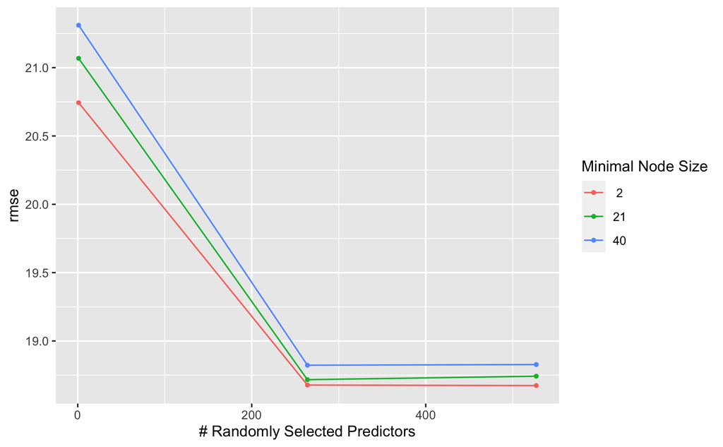

Random Forest RMSE Autoplot.

### Final Model

```
## # A tibble: 1 × 3
##   .metric .estimator .estimate
##   <chr>   <chr>          <dbl>
## 1 rmse    standard        17.8
```

The table below shows the individual prediction values for `TARGET_deathRate`, which are quite close to the actual values. The random forest model was thus determined to be both accurate and effective for predicting `TARGET_deathRate`through regression modeling.

```
## # A tibble: 764 × 5
##    .pred TARGET_deathRate .metric .estimator .estimate
##    <dbl>            <dbl> <chr>   <chr>          <dbl>
##  1  165.             165. rmse    standard        17.8
##  2  159.             161. rmse    standard        17.8
##  3  185.             195. rmse    standard        17.8
##  4  159.             144. rmse    standard        17.8
##  5  172.             184. rmse    standard        17.8
##  6  177.             178. rmse    standard        17.8
##  7  166.             165. rmse    standard        17.8
##  8  163.             163. rmse    standard        17.8
##  9  166.             163. rmse    standard        17.8
## 10  219.             237. rmse    standard        17.8
## # … with 754 more rows
```

## Limitations and Improvements

Some limitations of this project include missing data, which were dropped and imputed in our analyses. For example, variables like `PctSomeCol18_24`, which had 75% missingness, were removed but others such as `PctEmployed16_Over` with only 5% missingness were imputed using `step_impute_linear`. While this dataset was considerably large with 3047 observations spread over 34 variables, using a larger dataset with more variables could improve the performance of our models. Less missingness would also help to increase the reliability of the predictions for each model. While we refined our models through three different rounds using different recipes, adding more rounds of tuning could be another area for improvement. We could also test more models, such as ensemble models combining multiple models, to observe increased performance metrics and better predictions.

## Github Repo Link

https://github.com/STAT301III/final-project-youhere.git